# Pick Distribution Exploratory Data Analysis

### Questions

#### What is the typical survival rate?

First, let’s calculate the surival statistics for each season/week based on the game results.

```r
# Prepare Survival Statistics
df.survival <- df.dist %>%
  group_by(season, week) %>%
  filter(result == "W") %>%
  summarize(survive_pct = sum(pick_pct, na.rm = TRUE)) %>%
  ungroup() %>%
  group_by(season) %>%
  arrange(week) %>%
  mutate(remaining_pct = cumprod(survive_pct)) %>%
  ungroup() %>%
  add_row(season = unique(df.dist$season), week = 0, survive_pct = NA, remaining_pct = 1.0) %>%
  arrange(season, week)
```

Now, let’s review the basic survival curve for the last several seasons.

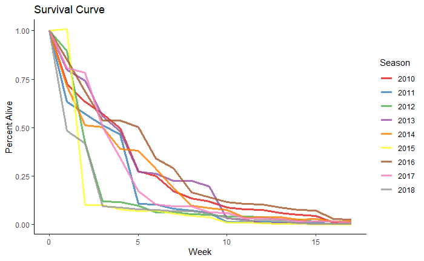

Let’s now consider the average case.

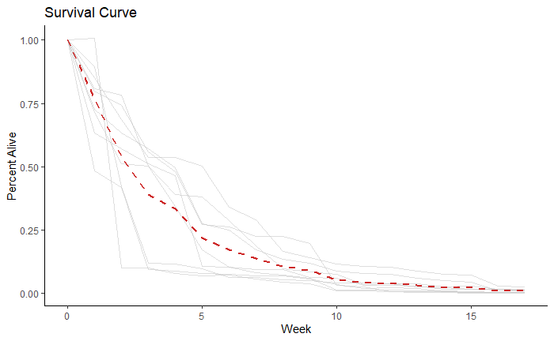

Let’s get some basic stats about how long people last in survivor pools.

| Remaining Percentage | Week |
| --- | --- |
| 0.25 | 4.7 |
| 0.10 | 8.4 |
| 0.05 | 10.2 |
| 0.01 | 16.6 |

The table above summarizes how long we would likely need to surive to make it to key thresholds such as 25%, 10%, 5% and 1% of the remaining pool.

This means that in sufficiently large pools (e.g. > 100), you would likely need to survive the entire season and likely into the playoffs to be the final survivor.

#### How does survival performanc change throughout the season?

Let’s look at distribution of surival rates for each week in the season.

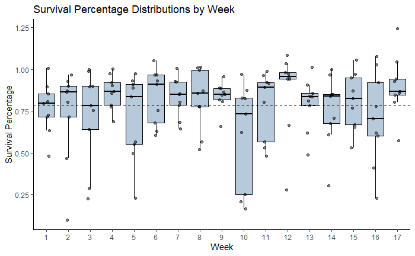

Oddly, there doesn’t appear to be a strong trend in survival percentage over time. This is fairly unexpected due to the fact that options for picks becomes more and more limited each week, hence, it would be expected that performance would down over time. Perhaps, this is counter-balanced by the fact that partcippants that make to to later weeks may have more experience/knowledge.

#### When do people typically utilize the best teams?

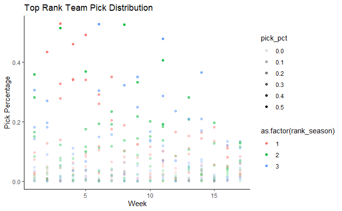